## **Long-nosed potoroo**

### Blamed on cats

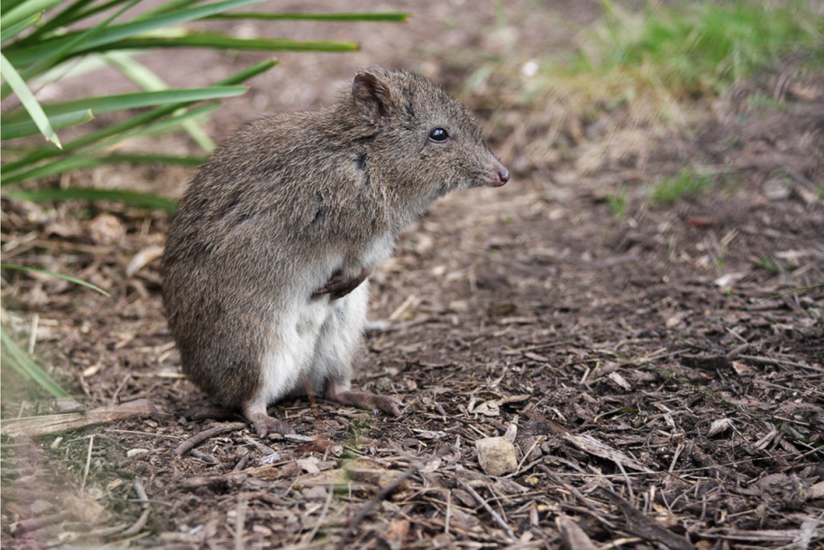

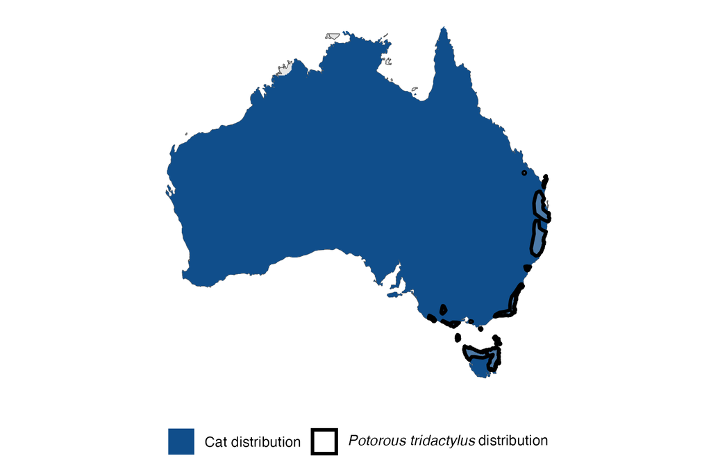

IUCN status: **Near Threatened**

EPBC Predator Threat Rating: **High**

IUCN claim: *“The major threat is predation, especially by the invasive Red Fox but also by wild dogs and feral cats.”*

### Studies in support

Remains of potoroo were found in the cat’s diet (Schwarz 1995; Lazenby 2012). Cats hunt potoroos (Miritis et al. 2020).

### Studies not in support

Rees et al. (2024) reported their analysis of over 1000 camera traps at two sites, which did not find a negative spatial association between potoroos and cats. Norton et al. (2015) reported that potoroos were more common at a site with cats, compared to a neighbouring site where no cats were detected. Miritis et al. (2020) reported that potoroos and abundant cats were positively correlated in space and in daily activity patterns and that cat presence did not affect potoroo detection probability. Long-nosed potoroo and cat occupancy were not correlated (Robley et al. 2022).

### Is the threat claim evidence-based?

No studies were found evidencing a negative association between cats and long-nosed potoroos. In contradiction with the claim, cats have been positively correlated with potoroos but causality cannot be determined due to confounding variables.

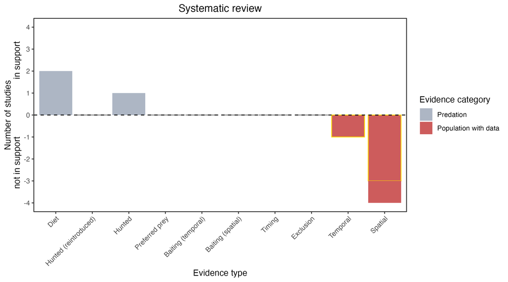

**Evidence linking *Potorous tridactylus* to cats.** Systematic review of evidence for an association between *Potorous tridactylus* and cats. Positive studies are in support of the hypothesis that *cats* contribute to the decline of Potorous tridactylus, negative studies are not in support. Predation studies include studies documenting hunting or scavenging; baiting studies are associations between poison baiting and threatened mammal abundance where information on predator abundance is not provided; population studies are associations between threatened mammal and predator abundance. Gold borders indicate studies that meet qualities of scientific rigour. See methods section in Wallach and Lundgren 2025 for details on evidence categories.

### References

EPBC. (2015) Threat Abatement Plan for Predation by Feral Cats. Environment Protection and Biodiversity Conservation Act 1999, Department of Environment, Government of Australia. (Table A1).

IUCN Red List. https://www.iucnredlist.org/ Accessed June 2023

Lazenby, B.T., 2012. Do feral cats affect small mammals? A case study from the forests of southern Tasmania. PhD thesis, University of Sydney, Sydney.

Miritis, V., Rendall, A.R., Doherty, T.S., Coetsee, A.L. and Ritchie, E.G., 2020. Living with the enemy: a threatened prey species coexisting with feral cats on a fox-free island. Wildlife Research, 47(8), pp.633-642.

Norton, M.A., Prentice, A., Dingle, J., French, K. and Claridge, A.W., 2015. Population characteristics and management of the long-nosed potoroo (Potorous tridactylus) in high-quality habitat in the Southern Highlands of New South Wales. Australian Mammalogy, 37(1), pp.67-74.

Rees, M.W., Wintle, B.A., Robley, A., Pascoe, J.H., Pla, M.L., Birnbaum, E.K. and Hradsky, B.A., 2024. Fox control and fire influence the occurrence of invasive predators and threatened native prey. Biological Invasions, 26(3), pp.685-703.

Robley, A.J., Cally, J.G., Murray, A., Bluff, L., Collyer, A., Borg, N. and Phillips, L., 2022. The response of native species to the 2019–20 bushfires and introduced predators in far East Gippsland. Arthur Rylah Institute for Environmental Research Technical Report Series No. 329. Department of Environment. Land, Water and Planning, Heidelberg.

Schwarz, E., 1995. Habitat use in a population of mainland Tasmanian feral cats, Felis catus. Graduate Diploma Honours Thesis. University of Tasmania, Hobart.

Wallach A.D., Lundgren E.J. (2025) Review of evidence that foxes and cats cause extinctions of Australia’s endemic mammals. BioScience. DOI: 10.1093/biosci/biaf046